# ME323 - Introdução aos Modelos Probabilísticos

## Teste de Hipóteses

## Relembrando: Teste de Hipóteses Passo-a-Passo

- **Passo 1**: Suposições
- **Passo 2**: Hipóteses
- **Passo 3**: Estatística do Teste
- **Passo 4**: Valor-de-p
- **Passo 5**: Conclusões

## Teste de Hipótese para uma proporção

Suponha que temos uma população e uma hipótese sobre a proporção \(p\) de indíviduos com certa característica

**Hipóteses:**  
\[ \begin{aligned} H_0: p = p_0 \quad \mbox{vs} \quad H_a: & p \neq p_0 \mbox{ (bilateral)} \\ & p < p_0 \mbox{ (unilateral à esquerda)} \\ & p > p_0 \mbox{ (unilateral à direita)} \end{aligned} \]

**Estatística do teste:** Baseada na distribuição amostral de \(\hat p\) \[Z=\frac{\hat{p}-p_0}{\sqrt{\frac{p_0(1-p_0)}{n}}} \overset{H_0}{\sim} N(0,1)\]

**Condição:** \(np_0 ≥ 10\) e \(n(1−p_0) ≥ 10\) para aproximação normal

## Teste de Hipótese para uma proporção

**valor-de-p**

- \(H_a: p \neq p_0\) (bilateral): valor-de-p=\(P(|Z| ≥|z_{obs}|)\)
- \(H_a: p < p_0\) (unilateral à esquerda): valor-de-p=\(P(Z \leq z_{obs})\)
- \(H_a: p > p_0\) (unilateral à direita): valor-de-p=\(P(Z \geq z_{obs})\)

**Conclusão**: Para um nível de significância \(\alpha\)

- Se valor-de-p \(\leq \alpha\): rejeitamos \(H_0\)
- Se valor-de-p > \(\alpha\): não rejeitamos \(H_0\)

## Valor-de-p Teste Bilateral

\(H_a: p \neq p_0\) (bilateral) \(\quad \Rightarrow \quad\) valor-de-p=\(P(|Z| ≥|z_{obs}|)\)

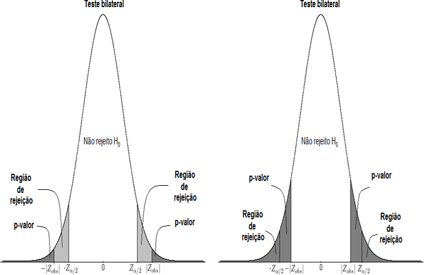

## Valor-de-p Teste Unilateral

\(H_a: p > p_0\) (unilateral à direita) \(\quad \Rightarrow \quad\) valor-de-p=\(P(Z \geq z_{obs})\)

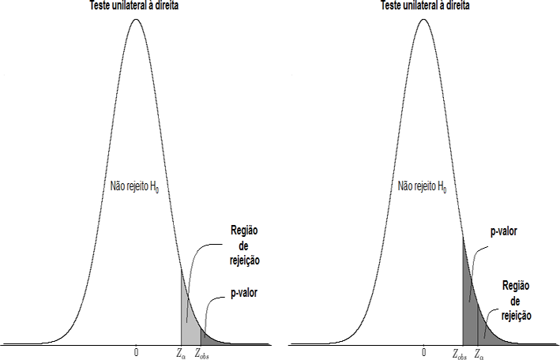

## Experimento da Coca vs Coca Zero

[figure not shown]

Em sala de aula, vários alunos disseram que conseguem distinguir entre Coca-Cola normal e Coca-Cola Zero.

Fizemos então o teste para comprovar se a afirmação é verdadeira.

Um dos alunos experimentou, em ordem aleatória, 20 amostras (ao acaso era Coca normal ou zero) e anotamos a quantidade de acertos.

> Cada tentativa, \(X_i\), é uma Bernoulli\((p)\), em que \(p\) é a probabilidade de acerto.

Veja que \(T=\sum_{i=1}^{20}X_i \sim Bin(20, p)\), onde \(T\) é o número de acertos.

Dos 20 testes, o aluno acertou 19! Temos então uma proporção amostral de acertos \(\hat p = 19/20=0.95\). Isso mostra que o aluno realmente sabe a diferença?

## Experimento da Coca vs Coca Zero

Vamos testar o seguinte: \[H_0: p = 0.50 \quad \mbox{vs} \quad H_a: p > 0.50\]

Podemos testar essas hipóteses de duas maneiras:

- Usando a aproximação normal para a proporção de acertos, como vimos na última aula, já que as condições \(np_0 \geq 10\) e \(n(1-p_0) \geq 10\) são satisfeitas.
- Usando a distribuição exata do número total de acertos

Vamos revisar o que vimos na aula passada e também fazer o teste com a distribuição exata de \(T\).

## Experimento da Coca vs Coca Zero

Usando a aproximação normal.

> **Hipóteses:** \(H_0: p = 0.50 \quad \mbox{vs} \quad H_a: p > 0.50\)

> A proporção amostral de acertos \(\hat p = \frac{T}{20}= 19/20=0.95\)

> **Estatística do teste:** \[z_{obs} = \frac{\hat p - p_0}{\sqrt{\frac{p_0(1-p_0)}{n}}} = \frac{0.95- 0.5}{\sqrt{\frac{(0.5)(0.5)}{20}}} = 4.02\]

> **valor-de-p** = \(P(Z \geq 4.02) = 0.00003\)

> **Conclusão:** Fixando \(\alpha=0.05\), rejeitamos a hipótese de que \(p=0.5\) e, portanto, acreditamos que a probabilidade de acertos é maior que 50%.

## Experimento da Coca vs Coca Zero

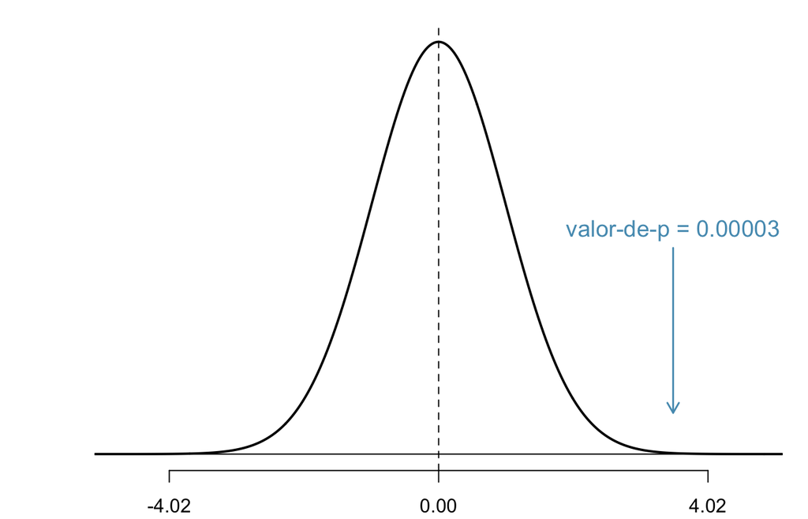

## Experimento da Coca vs Coca Zero

Usando a distribuição exata do número de acertos em 20 tentativas.

**Hipóteses:** \(H_0: p = 0.50 \quad \mbox{vs} \quad H_a: p > 0.50\)

**Hipóteses:** \(H_0: Acertos = 10 \quad \mbox{vs} \quad H_a: Acertos > 10\)

**Estatística do teste:** \(T= \sum_{i=1}^{20}X_i \overset{H_0}{\sim} Bin(20, 0.5)\)

O valor observado da estatística do teste é \(t_{obs}=19\), ou seja, o número total de acertos.

**valor-de-p** = \(P(T\geq 19)=0.00002\)

**Conclusão:** Fixando \(\alpha=0.05\), rejeitamos a hipótese de que \(p=0.5\) e, portanto, acreditamos que a probabilidade de acertos é maior que 50%.

## Experimento da Coca vs Coca Zero

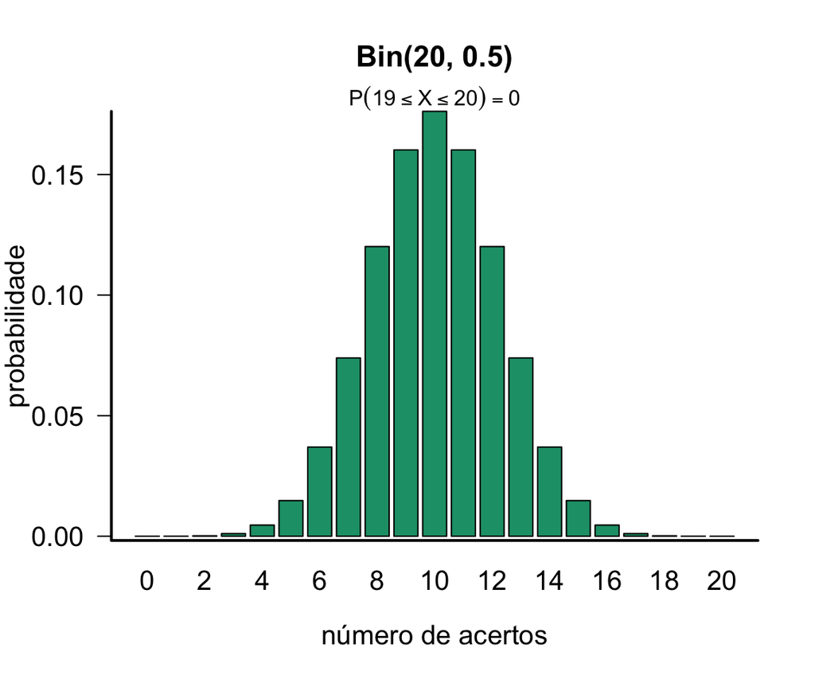

## Tipos de Erro

Quando realizamos um teste de hipóteses, podemos cometer 2 tipos de erros:

> 1- **Erro Tipo I:** Rejeitar a hipótese \(H_0\), quando tal hipótese é verdadeira

> 2- **Erro Tipo II:** Não rejeitar a hipótese \(H_0\), quando tal hipótese é falsa

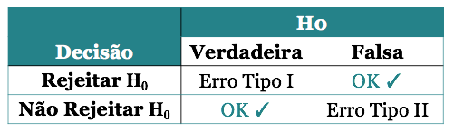

**Erro Tipo I:** erro mais grave

## Tipos de Erro

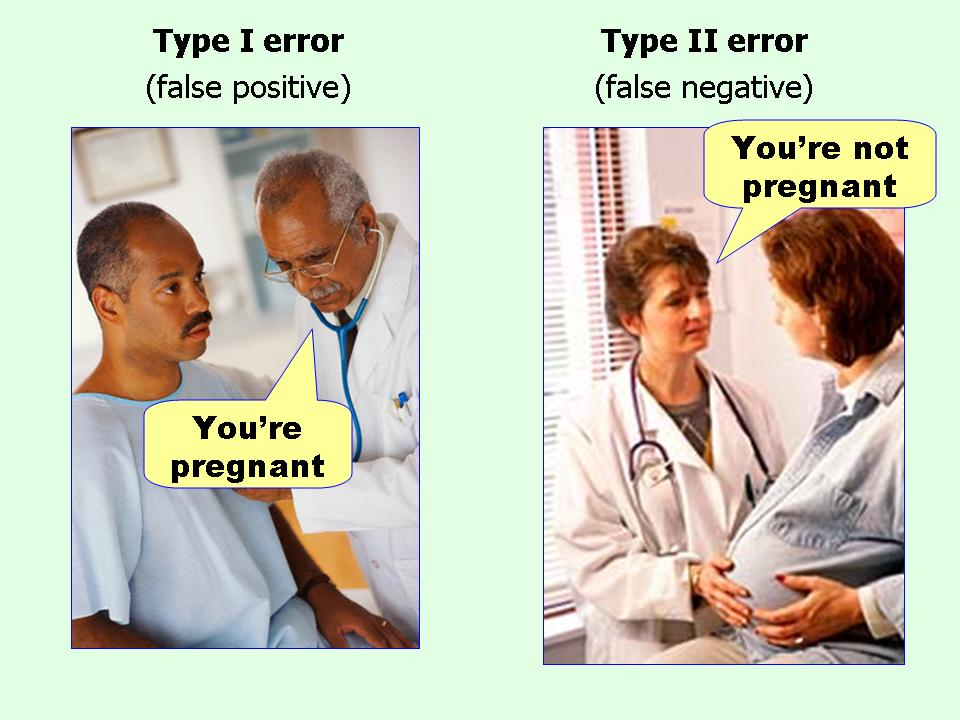

\(H_0: \mbox{você não está grávida(o)}\)

\(H_A: \mbox{você está grávida(o)}\)

## Tipos de Erro

Podemos calcular as probabilidades dos dois tipos de erro, chamadas de \(\alpha\) e \(\beta\):

\(\alpha = P(\mbox{Erro Tipo I}) = P(\mbox{Rejeitar } H_0| H_0 \mbox{ verdadeira})\)

\(\beta = P(\mbox{Erro Tipo II}) = P(\mbox{Não Rejeitar } H_0| H_0 \mbox{ falsa})\)

Na situação ideal, ambas as probabilidades de erro, \(\alpha\) e \(\beta\), seriam próximas de zero. Entretanto, à medida que diminuímos \(\alpha\), a probabilidade \(\beta\) tende a aumentar.

Levando isso em conta, em teste de hipóteses tentamos controlar a probabilidade do erro do tipo I, já que esse é o erro mais grave.

A probabilidade \(\alpha\) é chamada de **nível de significância**, que geralmente fixamos em \(5\%\).

## Tipos de Erro

No experimento da Coca-Cola tivemos 19 acertos em 20 tentativas e decidimos rejeitar \(H_0\).

Mas e se tivéssemos observado 14 acertos? Ou 12?

Existe um valor, \(t_c\), de maneira que se observarmos algo igual ou maior que ele decidimos rejeitar \(H_0\)?

Esse valor é chamado de **valor crítico** e vamos denotá-lo por \(t_c\).

## Tipos de Erro

No experimento da Coca-Cola: \(H_{0}: p=0.5 \quad \mbox{vs} \quad H_a: p>0.5\)

Seja \(T\) o número de acertos em uma amostra de tamanho \(n=20\). Então \(T \sim Bin(20,p)\).

Vamos considerar o seguinte valor crítico: \(t_c=12\).

Lembrando que \(T\) pode assumir os valores \(0,1,2,...,20\).

O valor crítico \(t_c\) determina as probabilidades de cometer os erros tipo I e II.

## Tipos de Erro

Considerando \(t_c=12\)

\[\begin{aligned} P(\mbox{Erro Tipo I}) & = P(\mbox{Rejeitar }H_{0}|H_{0}\mbox{ verdadeira}) \\ & = P(T \geq t_c|p=0.5) \\ & = \sum_{x=12}^{20}P(T=x|p=0.5) \approx 0.25 \end{aligned} \]

\[\begin{aligned} P(\mbox{Erro Tipo II}) & = P(\mbox{Não Rejeitar }H_{0}|H_{0}\mbox{ falsa}) \\ & = P(T < t_c|p=0.7) \\ & = \sum_{x=0}^{11}P(T=x|p=0.7) \approx 0.11 \end{aligned} \]

## Tipos de Erro

Observando a relação entre os erros tipo I e II, e \(t_c\): \(H_{0}: p=0.5 \; \mbox{vs} \; H_a: p=0.7\)

| \(t_c\) | P(Erro Tipo I) | P(Erro Tipo II) |
| --- | --- | --- |
| \(12\) | 0.25 | 0.11 |
| \(13\) | 0.13 | 0.23 |
| \(14\) | 0.06 | 0.39 |
| \(15\) | 0.02 | 0.58 |

Veja que à medida que \(\alpha=\)P(Erro Tipo I) diminui, \(\beta=\)P(Erro Tipo II) aumenta.

Então, optamos por controlar \(\alpha=\)P(Erro Tipo I), que é considerado o erro mais grave. Geralmente fixamos \(\alpha=0.05\) e rejeitamos \(H_0\) se valor-de-p \(<\alpha\).

## Teste de hipóteses para média (\(\sigma\) conhecido)

## Exemplo: Café

Vamos voltar no problema da máquina que enche pacotes de café. Digamos que o peso nominal do pacote de café seja de 500g. Assume-se que o desvio-padrão é conhecido (\(\sigma = 10\)).

> Retiraram uma amostra de 25 pacotes e observaram um peso médio de 485g.

> Isso nos traz evidência de que os pacotes têm menos de 500g?

> Já calculamos o IC de 95% para esse problema: \[IC(\mu, 0.95) = [481.08; 488.92]\]

> Vamos agora testar as hipóteses: \[H_0: \mu = 500 \quad \mbox{vs} \quad H_a: \mu \neq 500\]

## Exemplo: Café

**Suposições:** Seja \(X_i\) o peso do \(i\)-ésimo pacote de café. Sabemos que \(\mathbb E(X_i)=\mu\) e \(Var(X_i)=\sigma^2\). Coletou-se uma amostra de tamanho \(n=25\). Pelo TCL: \[\bar{X}\sim N(\mu,\sigma^2/n)\]

**Hipóteses:** \(H_0: \mu = \mu_0 = 500 \quad \mbox{vs} \quad H_a: \mu \neq \mu_0 = 500\)

**Estatística do teste**: \[Z = \frac{\bar{X}-\mu_0}{\sigma/\sqrt{n}} \overset{H_0}{\sim} N(0,1)\]

Considerando a amostra obtida: \[z_{obs} = \frac{485-500}{10/5}=-7.5\]

## Teste de hipóteses para média (\(\sigma\) conhecido)

Como medir se \(-7.5\) é evidência contra \(H_0\)?

O teste é bilateral, portanto o valor-de-p é calculado como:

**Valor-de-p**: \(P(|Z| \geq 7.5) = 2P(Z \geq 7.5) \approx 0\)

**Conclusão:** Como o valor-de-p é praticamente zero, rejeitamos \(H_0\), ou seja, rejeitamos a hipótese de que a média é 500g.

## Região Crítica (Região de Rejeição)

Outra forma de decidirmos se a evidência encontrada nos dados é forte o suficiente para rejeitar \(H_0\) é determinando a **região crítica** ou **região de rejeição**.

**Região Crítica:** conjunto de valores da estatística do teste para os quais a hipótese nula é rejeitada.

## Região crítica: teste bilateral

\(H_0: \mu=\mu_0\) vs \(H_a: \mu \neq \mu_0\) e um nível de significância \(\alpha\), definimos a região crítica do teste:

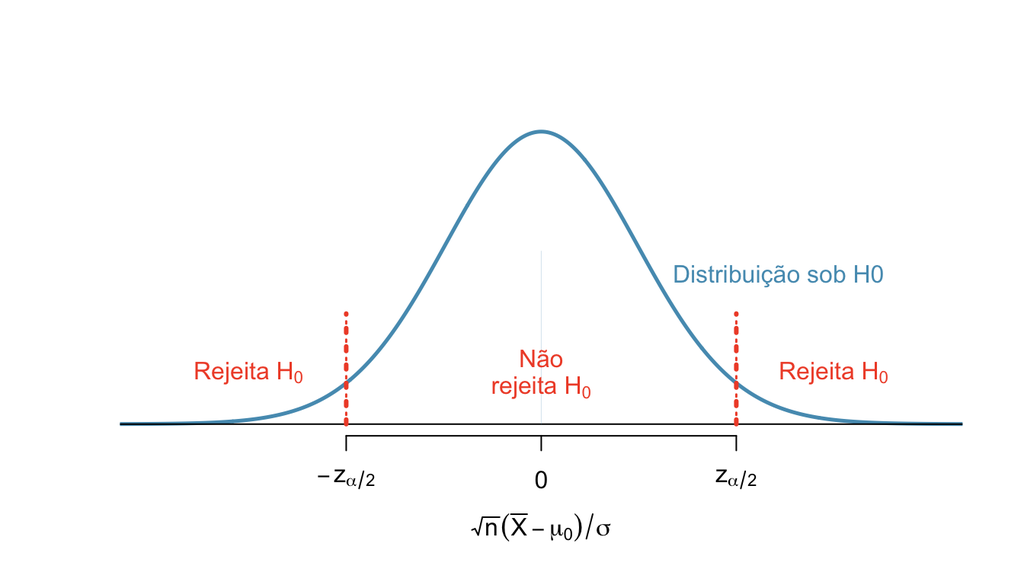

## Região crítica: teste unilateral à direita

\(H_0: \mu=\mu_0\) vs \(H_a: \mu > \mu_0\) e um nível de significância \(\alpha\), definimos a região crítica do teste:

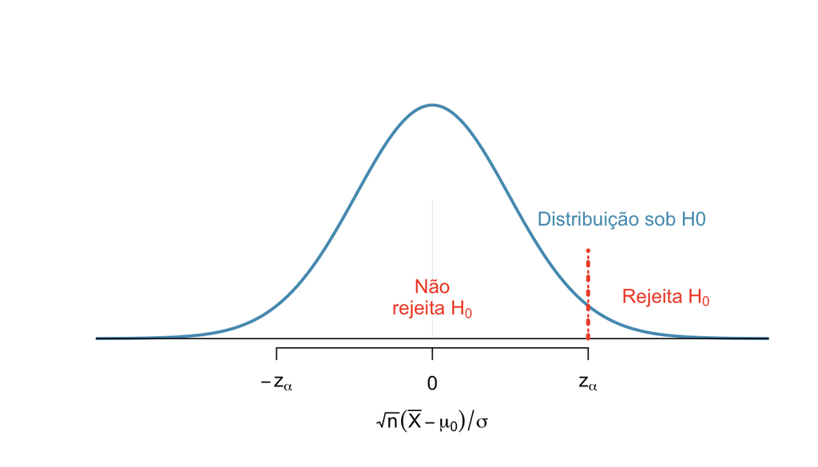

## Região crítica: teste unilateral à esquerda

\(H_0: \mu=\mu_0\) vs \(H_a: \mu < \mu_0\) e um nível de significância \(\alpha\), definimos a região crítica do teste:

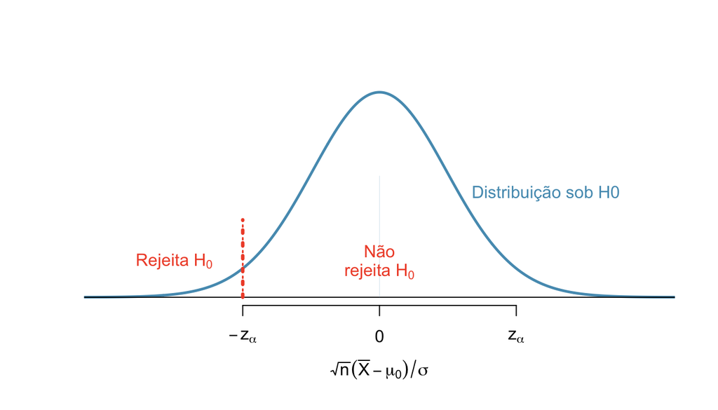

## Região Crítica: teste bilateral

Quando o teste for bilateral: \(H_0: \mu = 500 \quad \mbox{vs} \quad H_a: \mu \neq 500\)

A região critíca, para \(\alpha=0.05\), é a área em azul na figura abaixo:

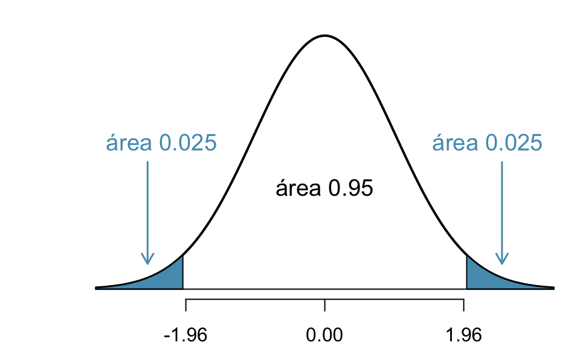

**Decisão:** Rejeitamos \(H_0\) se \(z_{obs} < -1.96\) ou \(z_{obs} > 1.96\).  
No nosso exemplo, \(z_{obs}=-7.5\). Portanto, rejeitamos \(H_0\).

## Região Crítica: teste unilateral à esquerda

Quando o teste for unilateral à esquerda: \(H_0: \mu = \mu_0 \quad \mbox{vs} \quad H_a: \mu < \mu_0\)

A região critíca, para \(\alpha=0.05\), é a área em azul na figura:

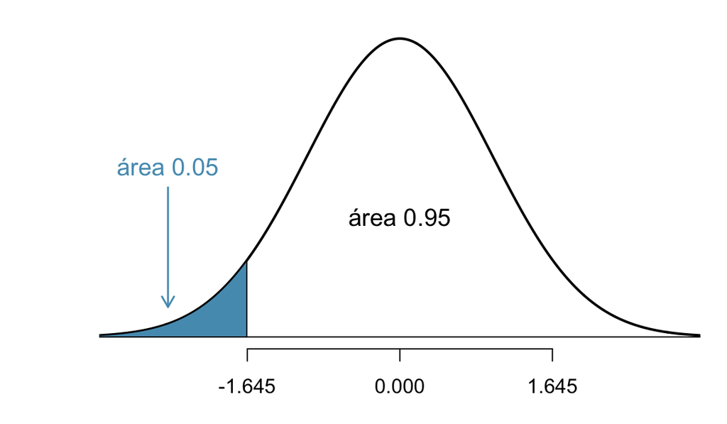

**Decisão:** Rejeitamos \(H_0\) se \(z_{obs} < -1.645\).

## Região Crítica: teste unilateral à direita

Quando o teste for unilateral à direita: \(H_0: \mu = \mu_0 \quad \mbox{vs} \quad H_a: \mu > \mu_0\)

A região critíca, para \(\alpha=0.05\), é a área em azul na figura:

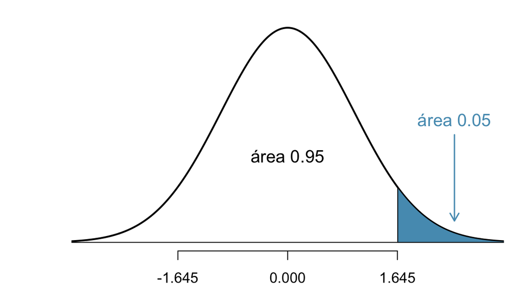

**Decisão:** Rejeitamos \(H_0\) se \(z_{obs} > 1.645\).

## Teste de hipóteses para média (\(\sigma\) desconhecido)

## Teste de hipóteses para média (\(\sigma\) desconhecido)

No caso de testar \[H_0: \mu = \mu_0 \quad \mbox{vs} \quad H_a: \mu \neq \mu_0\] quando \(\sigma\) é desconhecido e a amostra é pequena (\(n<30\)) devemos utilizar a distribuição \(t\).

**Estatística do teste**: \[t = \frac{\bar{X}-\mu_0}{s/\sqrt{n}} \overset{H_0}{\sim} t_{n-1}\]

**valor-de-p:** \(P(|t_{n−1}| ≥ |t_{obs}|) = 2P(t_{n−1} ≥ t_{obs})\)

Para as hipóteses unilaterais, o raciocínio é semelhante ao que foi feito anteriormente quando \(\sigma\) é conhecido.

## Teste de hipóteses para média (\(\sigma\) desconhecido)

No nosso exemplo, suponha que não sabemos o valor de \(\sigma\), mas o desvio padrão da amostra é 7.1g. Queremos testar \[H_0: \mu = 500 \quad \mbox{vs} \quad H_a: \mu \neq 500\]

**Estatística do teste:** \[t_{obs} = \frac{\bar{X}-\mu_0}{s/\sqrt{n}} = \frac{485-500}{7.1/5} = -10.56\]

**valor-de-p:** \(P(|t_{24}| ≥ 10.56) = 2P(t_{24} ≥ 10.56) \approx 0\)

**Conclusão:** Rejeitamos a hipótese de que a média é 500g.

**valor crítico:** para nível de significância \(\alpha=0.05\) e teste bilateral, \(t_{crit}\) é tal que \(P(t_{24}>t_{crit})=P(t_{24}<-t_{crit})=0.025\). De maneira que \(t_{crit}=2.06\). Portanto, se \(|t_{obs}|>t_{crit}\), rejeita-se \(H_0\).

## Exemplo: Dieta LowCarb

- 41 pacientes obesos, selecionados aleatoriamente, foram submetidos a uma dieta com baixa quantidade de carboidratos.
- Pesquisadores responsáveis pelo estudo acreditam que essa dieta faz com que os pacientes apresentem uma redução de peso.
- Após 16 semanas, a diferença média de peso foi \(-9.7\)kg, com desvio padrão \(3.4\) kg.
- O que podemos concluir deste estudo?

> Detalhes do estudo podem ser encontrados no artigo: Effect of 6-month adherence to a very low carbohydrate diet program.

## Exemplo: Dieta LowCarb

**Suposições**: \(X_i\) é a diferença entre peso inicial e final do \(i\)-ésimo obeso. Sabemos que \(\mathbb E(X_i)=\mu\) e \(Var(X_i)=\sigma^2\). Coletou-se uma amostra de tamanho \(n=41\). Pelo TCL: \[\bar{X}\sim N(\mu,\sigma^2/n)\]

**Hipóteses**: \(H_0: \mu= 0 \quad \mbox{vs} \quad H_a:\mu < 0\)

Ou seja, estamos testando se não há diferença no peso após a dieta versus a hipótese que há redução no peso após a dieta.

## Exemplo: Dieta LowCarb

**Estatística do teste**: Como \(n=41\), podemos usar a aproximação normal \[z_{obs}=\frac{\bar{X}-\mu_0}{s/\sqrt{n}}=\frac{-9.7-0}{3.4/\sqrt{41}}=-18.3\]

**Valor-de-p**: Como o teste é unilateral à esquerda \[\mbox{valor-de-p}=P(Z<-18.3) \approx 0\]

**Conclusão:** Como o valor-de-p é bem pequeno (<0.05) rejeitamos \(H_0\), ou seja, rejeitamos a hipótese de que a dieta não produz diferença no peso.

## Exemplo: Acidentes de trabalho

A associação dos proprietários de indústrias metalúrgicas está muito preocupada com o tempo perdido com acidentes de trabalho, cuja média, nos últimos tempos, tem sido da ordem de 60 horas/homem por ano e desvio padrão de 20 horas/homem.

Tentou-se um programa de prevenção de acidentes, após o qual foi tomada uma amostra de nove indústrias e medido o número de horas/homens perdidos por acidentes, que foi de 50 horas.

Você diria, no nível de \(5\%\), que há evidência de melhoria?

*Fonte: Morettin & Bussab*, Estatística Básica \(5^a\) edição, pág 334.

## Exemplo: Acidentes de trabalho

Queremos testar a hipótese que \(\mu\), o número médio de horas perdidas com acidentes de trabalho, tenha permanecido o mesmo. Ou seja, \[H_0: \mu = 60 \quad \mbox{vs} \quad H_a: \mu < 60\]

**Estatística do teste:** \[z_{obs} = \frac{\bar{X}-\mu_0}{\sigma/\sqrt{n}} = \frac{50-60}{20/3} = -1.5 \]

**valor-de-p:** \(P(Z \leq -1.5) = 0.067\)

**Conclusão:** Como o valor-de-p é maior que 0.05, não rejeitamos a hipótese de que a média é 60. Ou seja, não há evidência contra da hipótese de que o número médio de horas perdidas tenha se mantido o mesmo.

## Exemplo: Acidentes de trabalho

Podemos também determinar a região crítica.

Como temos um teste unilateral à esquerda, para um nível de significância de \(5\%\), rejeitamos \(H_0\) se \(z_{obs} < -z_{0.05} = -1.645\).

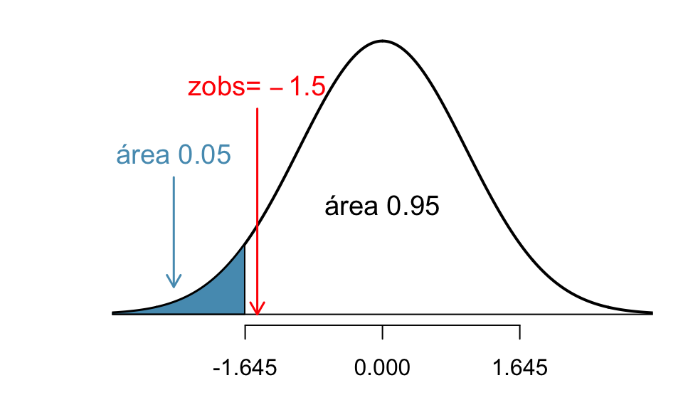

Como \(z_{obs}=-1.5 > -1.645\), então não rejeitamos \(H_0\).

## Resumo: Teste de hipóteses para média

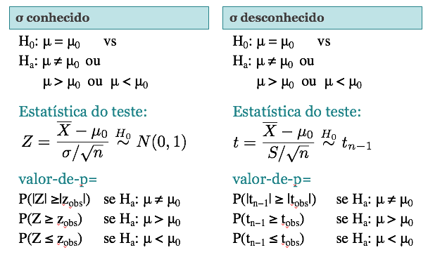

## Leituras

- Devore: capítulo 8.
- [Ross](http://www.sciencedirect.com/science/article/pii/B9780123743886000090): capítulo 9.
- [OpenIntro](https://www.openintro.org/stat/textbook.php): seção 5.1.
- Magalhães: capítulo 8.

Slides produzidos pelos professores:

- Samara Kiihl
- Tatiana Benaglia
- Benilton Carvalho